# Population-specific effects of randomness on isoform expression

J. Ignacio Lucas Lledó

23/12/2019

One of the conclusions in `2019-04-03` was that there is a significant interaction between the effects of the regime and of the original population. That means that not all populations responded equally to a specific selective regime. We need to take this into account to decide what contrasts are interesting. Not only the isoforms that are *on average* differently expressed in regular than in random environments are interesting. The specific response of each random population may have biological meaning.

On `2019-04-03` we also determined that there are no isoforms with a significant interaction between selective regime and hatching condition. This may be a simple consequence of the fact that not all populations respond similarly to the selective regimes: in this situation, there are just not enough replicates to detect an interaction between regime and hatching condition.

# Isoforms expressed *on average* differently between random and regular regimes

When I first tested the effect of randomness on expression level using model 4 and 6 on `2019-04-03`, I tested for a significant second coefficient, which corresponds to the expression level of a sample from original population 1 under a random regime, relative to the expression level of population 3, under a regular regime. That does not seem to be what I want. To make it easier to express a contrast that compares all random populations to all regular ones, I will use a different model.

```r
counts <- read.table(COUNTS_FILE, row.names=1, header=TRUE)
regimePop <- factor(c('random1',  'random1',  'random2',  'random2',
                      'regular1', 'regular1', 'random3',  'random3',
                      'regular2', 'regular2', 'regular3', 'regular3'))
diapause   <- factor(rep(c("hatch","diapause"), 6))
diapause   <- relevel(diapause, "hatch")

# Filtering
y <- DGEList(counts=counts, group=regimePop)
y <- calcNormFactors(y, method="TMM")
threshold <- 5.0 / (min(y$samples$lib.size) / 1000000)
keep <- rowSums(cpm(y) > threshold) >= 4
y <- y[keep, ,keep.lib.sizes=FALSE]
NumOfTags <- dim(y)[1]
design7 <- model.matrix(~ 0 + regimePop + diapause)
row.names(design7) <- names(counts)
reactable(design7, columns=list(
  regimePoprandom1 = colDef(name='Random.1'),
  regimePoprandom2 = colDef(name='Random.2'),
  regimePoprandom3 = colDef(name='Random.3'),
  regimePopregular1 = colDef(name='Regular.1'),
  regimePopregular2 = colDef(name='Regular.2'),
  regimePopregular3 = colDef(name='Regular.3'),
  diapausediapause = colDef(name='diapause')))
```

|  | Random.1 | Random.2 | Random.3 | Regular.1 | Regular.2 | Regular.3 | diapause |
| --- | --- | --- | --- | --- | --- | --- | --- |
| X1A_S8 | 1 | 0 | 0 | 0 | 0 | 0 | 0 |
| X1C_S1 | 1 | 0 | 0 | 0 | 0 | 0 | 1 |
| X2A_S7 | 0 | 1 | 0 | 0 | 0 | 0 | 0 |
| X2C_S5 | 0 | 1 | 0 | 0 | 0 | 0 | 1 |
| X3A_S9 | 0 | 0 | 0 | 1 | 0 | 0 | 0 |
| X3C_S11 | 0 | 0 | 0 | 1 | 0 | 0 | 1 |
| X4A_S6 | 0 | 0 | 1 | 0 | 0 | 0 | 0 |
| X4C_S12 | 0 | 0 | 1 | 0 | 0 | 0 | 1 |
| X5A_S2 | 0 | 0 | 0 | 0 | 1 | 0 | 0 |
| X5C_S4 | 0 | 0 | 0 | 0 | 1 | 0 | 1 |

[output cut: 2 more lines]

```r
y7 <- estimateDisp(y, design7)
fit7 <- glmQLFit(y7, design7)
randomness <- glmQLFTest(fit7, contrast = c(1/3, 1/3, 1/3, -1/3, -1/3, -1/3, 0))
```

By treating populations independently, model 7 neither assumes nor estimates whatever common effect populations in the same regime may share.

Instead of reporting the number of significantly regulated isoforms under a specific FDR, I report here the overall, FDR-independent, estimated fraction of regulated isoforms. There are ways to estimate the number of true null hypotheses even when there is a dependence structure among tests. I found the package `cp4p` (Gianetto et al. 2016. Proteomics, 16(1), 29-32.), that does exactly that. The SLIM method [Want et al. 2011](https://academic.oup.com/bioinformatics/article/27/2/225/286449), is supposed to be adequate for datasets with dependence structure, but I think here it overestimates the proportion of non-regulated isoforms.

```r
randomness.pi0 <- estim.pi0(randomness$table$PValue)
randomness.pi0
```

```
## $pi0.est
##   pi0.Storey.Spline pi0.Storey.Boot pi0.Jiang pi0.Histo pi0.Langaas pi0.Pounds
## 1          0.299656       0.3113136 0.3095419 0.3087826     0.30914  0.4074279
##    pi0.ABH  pi0.SLIM
## 1 0.618284 0.5368003
```

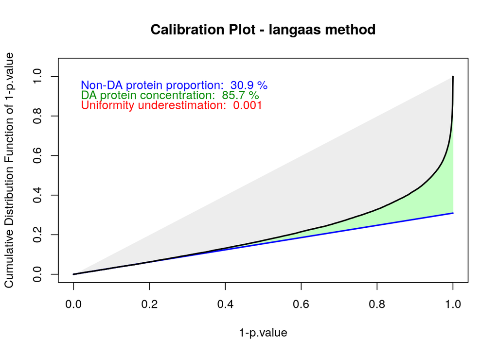

```
## $pi0
## [1] 0.30914
##
## $h1.concentration
## [1] 0.8576628
##
## $unif.under
## [1] 0.001900554
```

```r
calibration.plot(randomness$table$PValue, pi0.method = 'langaas')
```

```r
topTags(randomness)
```

```
## Coefficient:  0.333333333333333*regimePoprandom1 0.333333333333333*regimePoprandom2 0.333333333333333*regimePoprandom3 -0.333333333333333*regimePopregular1 -0.333333333333333*regimePopregular2 -0.333333333333333*regimePopregular3
##                     logFC    logCPM        F       PValue         FDR
## TCONS_00026548 -2.2147404 3.9744396 297.6058 4.240137e-08 0.001396065
## TCONS_00039988  3.4376344 2.8430068 247.9886 9.261414e-08 0.001524660
## TCONS_00003241 -3.4242790 2.9158822 220.6685 1.523447e-07 0.001671983
## TCONS_00039978 -4.7308843 0.2260114 197.3874 2.446125e-07 0.002013467
## TCONS_00022690 -2.2400845 3.3004990 149.9287 7.793765e-07 0.003935117
## TCONS_00011853 -2.5829379 2.9400725 141.9000 9.810441e-07 0.003935117
## TCONS_00050342  3.6064695 3.0043032 141.3008 9.985288e-07 0.003935117
## TCONS_00056568  1.5210573 4.1573553 140.7805 1.014022e-06 0.003935117
## TCONS_00017572  0.9675738 7.1997413 134.2867 1.234621e-06 0.003935117
## TCONS_00031392 -2.7443589 4.5499997 133.9729 1.246702e-06 0.003935117
```

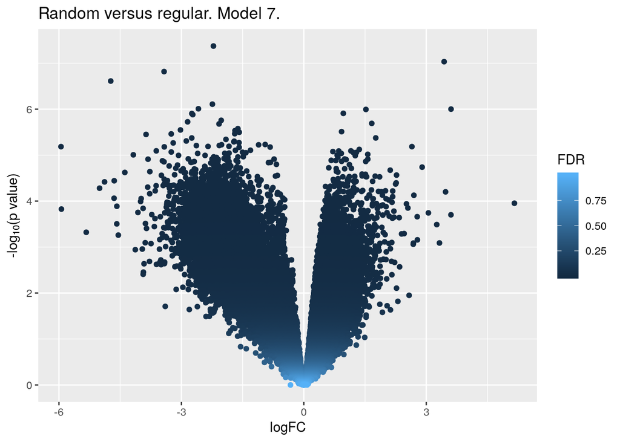

```r
z1 <- topTags(randomness, n=NumOfTags)$table
z1$logPValue <- -log10(z1$PValue)
ggplot(data=z1, mapping=aes(x=logFC, y=logPValue, color=FDR)) +
   geom_point() + theme_grey() + ylab(expression(paste("-log"[10], plain("(p value)")))) +
   ggtitle('Random versus regular. Model 7.')
```

```r
rm(z1)
```

According to this test, at least 38 and up to 70% of isoforms are differentially expressed on average between regular and random regimes.

# Isoforms expressed differently in random population 1 than in the average regular population

Using again model 7, now I want to determine what isoforms are expressed differently in random population 1, with respect to the average regular population.

```r
random1 <- glmQLFTest(fit7, contrast = c(1, 0, 0, -1/3, -1/3, -1/3, 0))
random1.pi0 <- estim.pi0(random1$table$PValue)
random1.pi0
```

```
## $pi0.est
##   pi0.Storey.Spline pi0.Storey.Boot pi0.Jiang pi0.Histo pi0.Langaas pi0.Pounds
## 1         0.5032853       0.5075171 0.5115853 0.5069704   0.5064049  0.6160823
##     pi0.ABH pi0.SLIM
## 1 0.9771602  0.78568
```

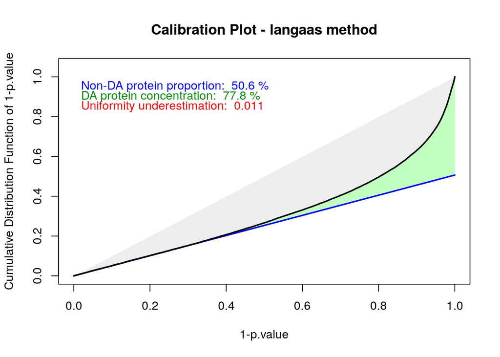

```
## $pi0
## [1] 0.5064049
##
## $h1.concentration
## [1] 0.7782396
##
## $unif.under
## [1] 0.01147115
```

```r
calibration.plot(random1$table$PValue, pi0.method = 'langaas')
```

```r
topTags(random1)
```

```
## Coefficient:  1*regimePoprandom1 -0.333333333333333*regimePopregular1 -0.333333333333333*regimePopregular2 -0.333333333333333*regimePopregular3
##                    logFC     logCPM         F       PValue         FDR
## TCONS_00063463 -4.742773  5.7121325 276.65961 5.799086e-08 0.001701417
## TCONS_00039988  3.984885  2.8430068 241.69981 1.033511e-07 0.001701417
## TCONS_00032909  5.450094 -0.2673881 213.30353 1.760067e-07 0.001931673
## TCONS_00039966  4.476663  0.0114170 149.08834 7.979348e-07 0.006257720
## TCONS_00063464 -3.443530  3.4154358 142.98603 9.502992e-07 0.006257720
## TCONS_00017572  1.255424  7.1997413 130.12497 1.407335e-06 0.007722752
## TCONS_00030498 -1.587199  4.7766284 113.05630 2.518140e-06 0.011844252
## TCONS_00000477  4.928940 -0.4136681 101.85031 3.865258e-06 0.015907951
## TCONS_00007289  3.553943  2.0938192  93.39269 5.504062e-06 0.017263688
## TCONS_00042651  1.529046  3.6161435  92.20618 5.797462e-06 0.017263688
```

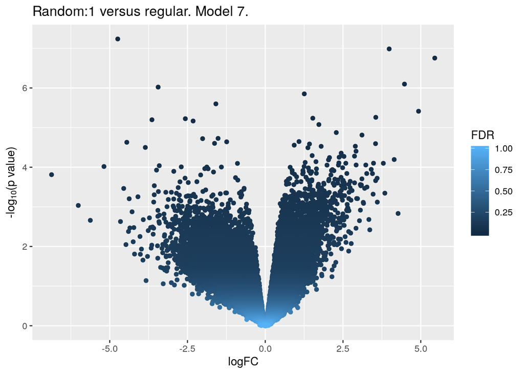

```r
z1 <- topTags(random1, n=NumOfTags)$table
z1$logPValue <- -log10(z1$PValue)
ggplot(data=z1, mapping=aes(x=logFC, y=logPValue, color=FDR)) +
   geom_point() + theme_grey() + ylab(expression(paste("-log"[10], plain("(p value)")))) +
   ggtitle('Random:1 versus regular. Model 7.')
```

```r
rm(z1)
```

According to this test, at least 2 and up to 50% of isoforms are expressed differently in population 1, under a random regime, relative to the average across populations in the regular regime.

# Isoforms expressed differently in random population 2 than in the average regular population

Next, we examine population 2, also under a random regime, relative to the average of populations under the regular regime.

```r
random2 <- glmQLFTest(fit7, contrast = c(0, 1, 0, -1/3, -1/3, -1/3, 0))
random2.pi0 <- estim.pi0(random2$table$PValue)
random2.pi0
```

```
## $pi0.est
##   pi0.Storey.Spline pi0.Storey.Boot pi0.Jiang pi0.Histo pi0.Langaas pi0.Pounds
## 1         0.3402528       0.3571754 0.3529942 0.3538345   0.3494089  0.4407115
##    pi0.ABH  pi0.SLIM
## 1 0.621473 0.5682517
```

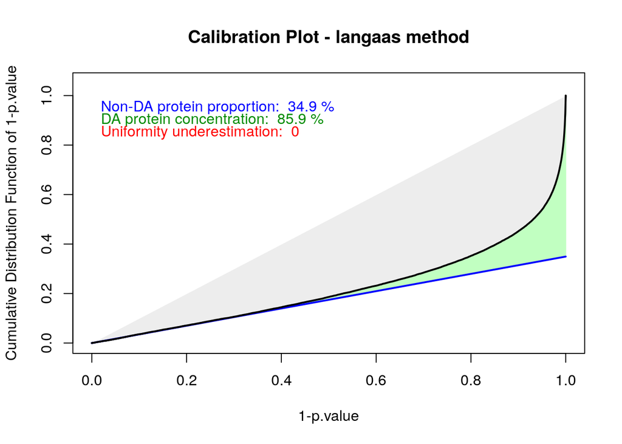

```
## $pi0
## [1] 0.3494089
##
## $h1.concentration
## [1] 0.8595354
##
## $unif.under
## [1] 3.86919e-05
```

```r
calibration.plot(random2$table$PValue, pi0.method = 'langaas')
```

```r
topTags(random2)
```

```
## Coefficient:  1*regimePoprandom2 -0.333333333333333*regimePopregular1 -0.333333333333333*regimePopregular2 -0.333333333333333*regimePopregular3
##                    logFC   logCPM        F       PValue          FDR
## TCONS_00026548 -5.460381 3.974440 479.7837 5.394085e-09 0.0001776003
## TCONS_00013860  3.359023 3.790964 314.7185 3.334526e-08 0.0003770598
## TCONS_00033569  4.947991 1.246348 312.5401 3.435625e-08 0.0003770598
## TCONS_00030123  2.550246 4.216033 269.7722 6.460515e-08 0.0004563323
## TCONS_00039988  4.141230 2.843007 260.8049 7.466456e-08 0.0004563323
## TCONS_00022690 -5.773254 3.300499 254.3170 8.315850e-08 0.0004563323
## TCONS_00064052 -3.997710 3.659217 239.4014 1.076529e-07 0.0005063533
## TCONS_00003241 -5.927786 2.915882 186.2795 3.125864e-07 0.0012864886
## TCONS_00065014 -5.958644 2.163157 174.7470 4.094287e-07 0.0013579188
## TCONS_00024172  1.636239 4.512094 173.8696 4.182124e-07 0.0013579188
```

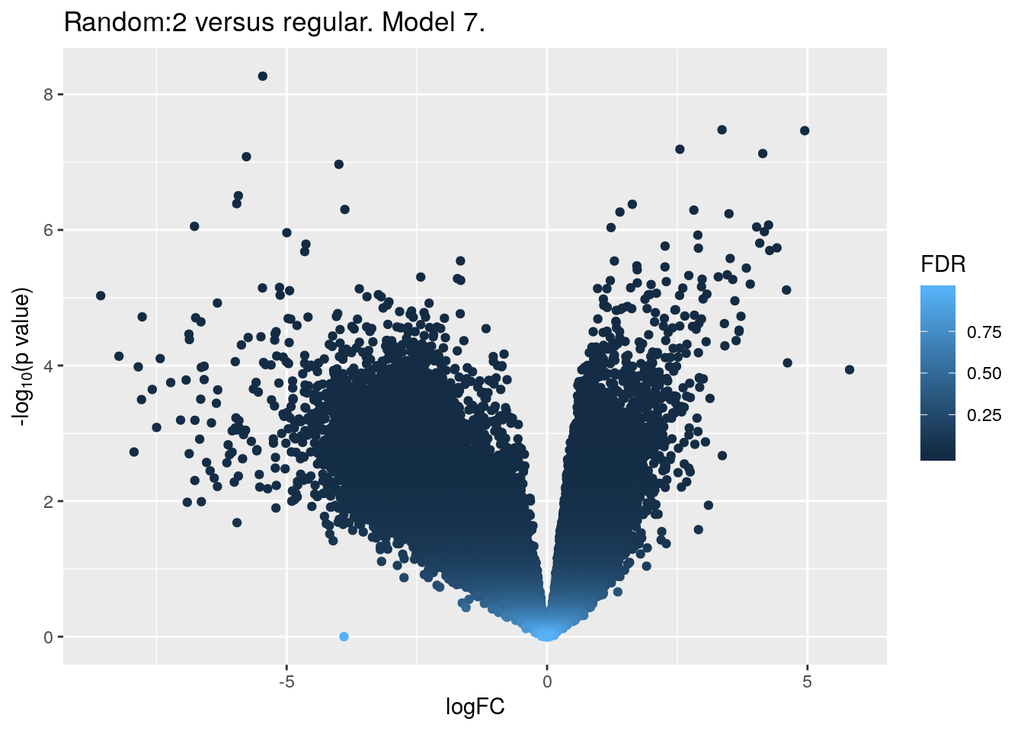

```r
z1 <- topTags(random2, n=NumOfTags)$table
z1$logPValue <- -log10(z1$PValue)
ggplot(data=z1, mapping=aes(x=logFC, y=logPValue, color=FDR)) +
   geom_point() + theme_grey() + ylab(expression(paste("-log"[10], plain("(p value)")))) +
   ggtitle('Random:2 versus regular. Model 7.')
```

```r
rm(z1)
```

According to this test, at least 38 and up to 66% of isoforms are expressed differently in population 2, under a random regime, relative to the average across populations in the regular regime.

# Isoforms expressed differently in (random) population 4 than in the average regular population

The third population under a random regime is labeled *4* in samples names. Let’s see what and how many isoforms are expressed differently in that population, relative to those under regular regime:

```r
random3 <- glmQLFTest(fit7, contrast = c(0, 0, 1, -1/3, -1/3, -1/3, 0))
random3.pi0 <- estim.pi0(random3$table$PValue)
random3.pi0
```

```
## $pi0.est
##   pi0.Storey.Spline pi0.Storey.Boot pi0.Jiang pi0.Histo pi0.Langaas pi0.Pounds
## 1         0.4292682       0.4325993 0.4359529 0.4246014   0.4305122  0.5222531
##     pi0.ABH  pi0.SLIM
## 1 0.7327563 0.6695388
```

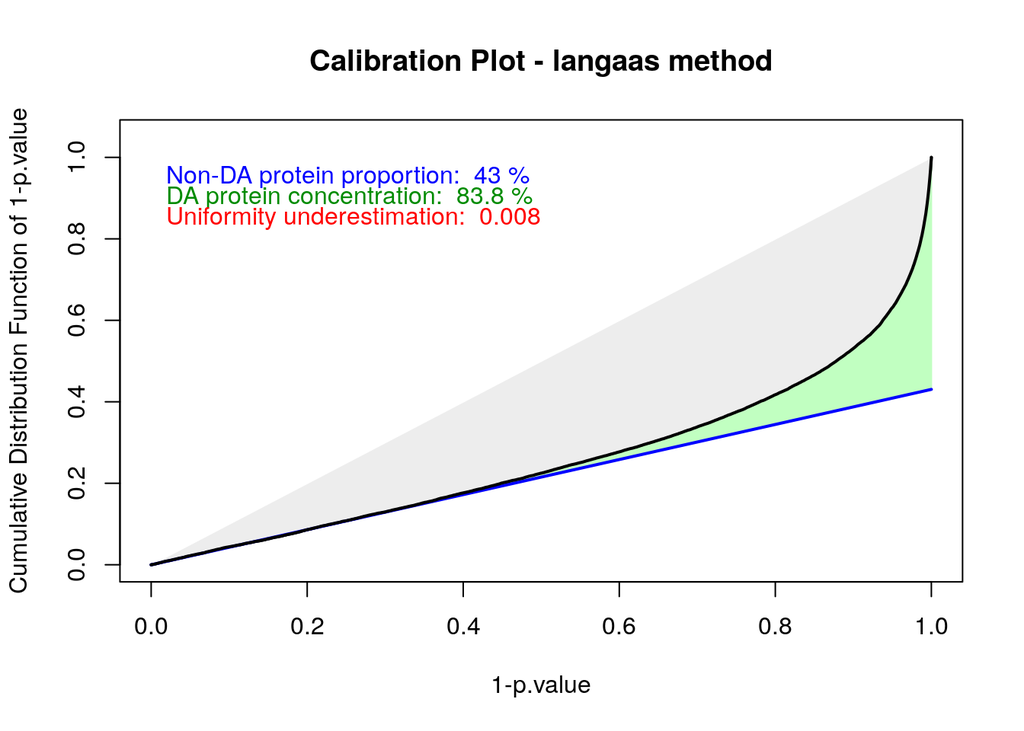

```
## $pi0
## [1] 0.4305122
##
## $h1.concentration
## [1] 0.8389812
##
## $unif.under
## [1] 0.008424471
```

```r
calibration.plot(random3$table$PValue, pi0.method = 'langaas')
```

```r
topTags(random3)
```

```
## Coefficient:  1*regimePoprandom3 -0.333333333333333*regimePopregular1 -0.333333333333333*regimePopregular2 -0.333333333333333*regimePopregular3
##                    logFC     logCPM        F       PValue         FDR
## TCONS_00056568  2.675419  4.1573553 277.5823 5.716920e-08 0.001709804
## TCONS_00004775  4.072793 -0.2744226 198.4707 2.390034e-07 0.001709804
## TCONS_00025027  4.704213  1.8557653 196.3962 2.498878e-07 0.001709804
## TCONS_00050342  5.001383  3.0043032 195.7235 2.535469e-07 0.001709804
## TCONS_00045925 -3.356140  4.1193154 194.6275 2.596513e-07 0.001709804
## TCONS_00000876 -5.997337  3.4175551 164.5554 5.273399e-07 0.002893778
## TCONS_00029849  1.242493  6.4065204 156.9976 6.425038e-07 0.003022063
## TCONS_00003241 -4.724201  2.9158822 145.5324 8.827243e-07 0.003632962
## TCONS_00007126  2.382429  2.7559632 131.3547 1.353376e-06 0.004951101
## TCONS_00002120  2.922460  5.3663658 121.6088 1.863393e-06 0.006135221
```

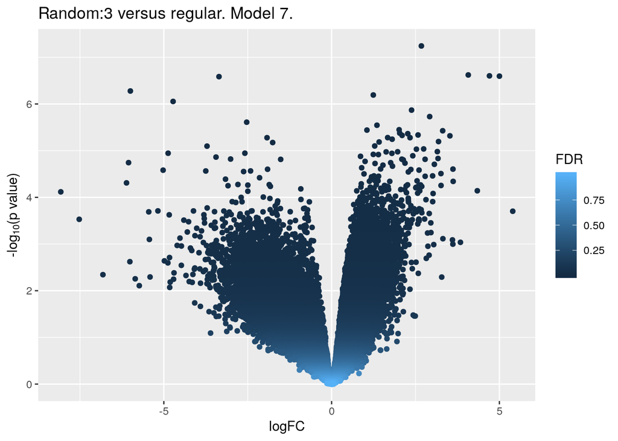

```r
z1 <- topTags(random3, n=NumOfTags)$table
z1$logPValue <- -log10(z1$PValue)
ggplot(data=z1, mapping=aes(x=logFC, y=logPValue, color=FDR)) +
   geom_point() + theme_grey() + ylab(expression(paste("-log"[10], plain("(p value)")))) +
   ggtitle('Random:3 versus regular. Model 7.')
```

```r
rm(z1)
```

According to this test, at least 27 and up to 58% of isoforms are expressed differently in population 3, under a random regime, relative to the average across populations in the regular regime.

# Isoforms always expressed differently in a random population than in the average regular population

The scatterplot of p-values is not expected to produce any visible correlation, unless for the smallest p-values. Plotting p-values in logarithmic scale does show that man isoforms differentially expressed in any population under the random regime is also differentially expressed in the other populations in the same regime.

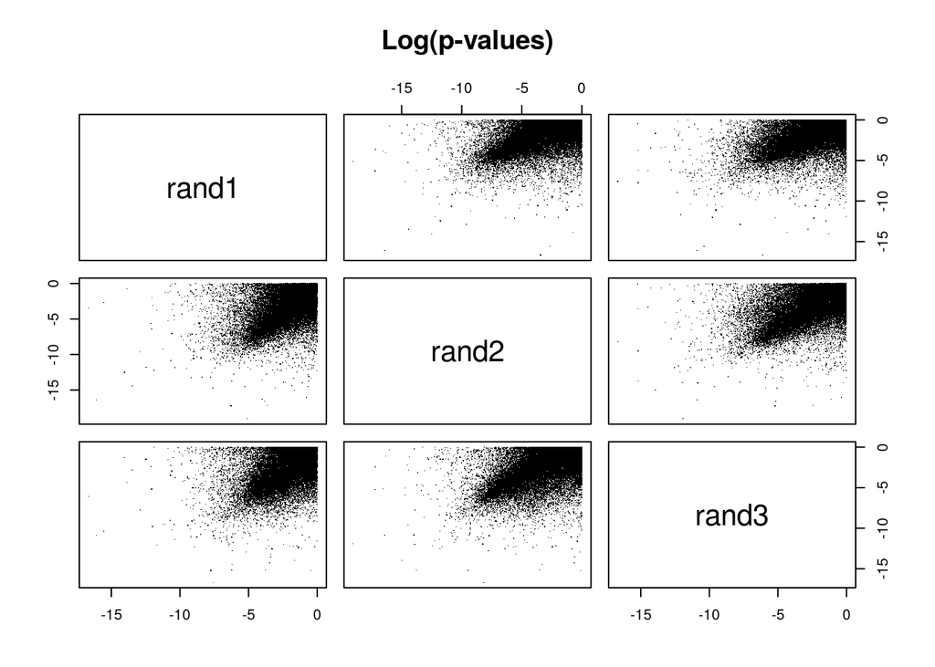

```r
pairs(data.frame(rand1=log(random1$table$PValue),
                 rand2=log(random2$table$PValue),
                 rand3=log(random3$table$PValue)),
      pch=".", main='Log(p-values)')
```

What about the log-fold change? Does the random regime change isoform expression in the same direction in all populations? Yes:

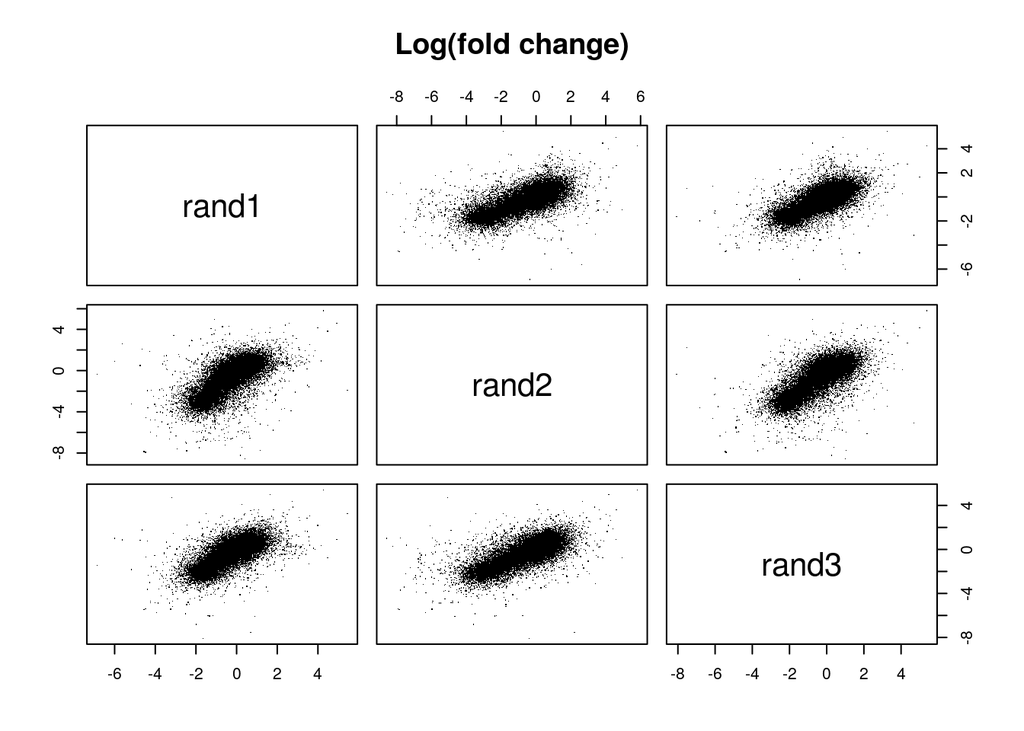

```r
pairs(data.frame(rand1=random1$table$logFC,
                 rand2=random2$table$logFC,
                 rand3=random3$table$logFC),
      pch = ".", main = 'Log(fold change)')
```

Given the large number of regulated isoforms, I can use a conservative FDR to compare the most significantly regulated isoforms among populations in the random regime.

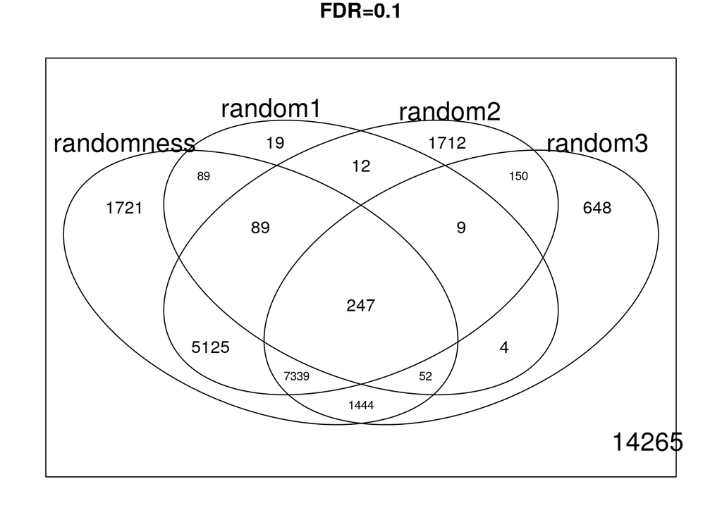

```r
significant <- cbind(randomness = topTags(randomness, n=NumOfTags, sort.by='none', adjust.method='fdr')$table$FDR <= 0.1,
                     random1 = topTags(random1, n=NumOfTags, sort.by='none', adjust.method='fdr')$table$FDR <= 0.1,
                     random2 = topTags(random2, n=NumOfTags, sort.by='none', adjust.method='fdr')$table$FDR <= 0.1,
                     random3 = topTags(random3, n=NumOfTags, sort.by='none', adjust.method='fdr')$table$FDR <= 0.1)
vennDiagram(vennCounts(significant), main='FDR=0.1')
```

# Writing up the results

I should save the results of the `glmQLFTest()` to run the functional analysis on the lists of regulated isoforms in a different session. I think it’s also good practice to save a plain text copy of the main tables, to allow inspection outside R.

```r
save(randomness, random1, random2, random3, file = 'isoforms/RegimeEffect_model7.RData')
write.table(topTags(randomness, n=NumOfTags)[[1]],
            file = 'isoforms/randomness.txt',
            quote = FALSE)
write.table(topTags(random1, n=NumOfTags)[[1]],
            file = 'isoforms/random1.txt',
            quote = FALSE)
write.table(topTags(random2, n=NumOfTags)[[1]],
            file = 'isoforms/random2.txt',
            quote = FALSE)
write.table(topTags(random3, n=NumOfTags)[[1]],
            file = 'isoforms/random3.txt',
            quote = FALSE)
```